# Log

## 20241204

1. Update github link
2. Add chapter 9: Tips & Tricks - Analysis workflow of protein expression

## 20240603

Installing Azimuth with the latest version

```r
remotes::install_github('satijalab/azimuth', ref = 'master')
```

## 20240507

Seurat V4 Optional: The materials are updated to Seurat V5. If you want to use Seurat V4, you can follow the below instruction to install Seurat V4. Please note that you may need to adapt the code to fit Seurat V4 structure.

First check the version of installed SeuratObject and Seurat.

```r
packageVersion("SeuratObject")
packageVersion("Seurat")
```

If the version is 5.0.x, please follow the below instructions to remove the existing Seurat package and install Seurat V4.

```r
remove.packages("SeuratObject")
remove.packages("Seurat")

packageurl <- "https://cran.r-project.org/src/contrib/Archive/SeuratObject/SeuratObject_4.1.4.tar.gz"
install.packages(packageurl, repos=NULL, type="source")

packageurl <- "https://cran.r-project.org/src/contrib/Archive/Seurat/Seurat_4.4.0.tar.gz"
install.packages(packageurl, repos=NULL, type="source")

# Validate the installation is successful by running packageVersion.

packageVersion("SeuratObject")
packageVersion("Seurat")
```

## 20240423

Extra plots

```r
seuratObj$test <- ifelse(seuratObj$nFeature_RNA < 300 | seuratObj$nCount_RNA < 500, "low", "high")


seuratObj@meta.data %>%
  ggplot(aes(x=nCount_RNA, y=nFeature_RNA, color=test)) +
  geom_point() +
  scale_colour_manual(values = c("black", "white")) +
  # stat_smooth(method=lm) +
  scale_x_log10() +
  scale_y_log10() +
  theme_classic() +
  geom_vline(xintercept = 500, colour = "red") +
  geom_hline(yintercept = 300, colour = "red") +
  facet_wrap(~Sample_Name) +
  theme(axis.text.x = element_text(angle = 90, vjust = 0.5, hjust=1))
```

Move “multiplet” and “undetermined” removal to Chapter 02 Quality Control

Chapter 01 Update data import

```r
# update Seurat object
seuratObj[["RNA"]] <- as(object = seuratObj[["RNA"]], Class = "Assay5")

# get bioproduct names for RNA and AbSeq
ab_name <- grep("pAbO", rownames(seuratObj), value = T, ignore.case = T)
rna_name <- rownames(seuratObj)[-which(rownames(seuratObj) %in% ab_name)]

# get rna and AbSeq UMI counts, meta data
ab <- GetAssayData(seuratObj[["RNA"]], features = ab_name)
rna <- GetAssayData(seuratObj[["RNA"]], features = rna_name)

# recreate seurat object
seuratObj[["RNA"]] <- CreateAssay5Object(counts = rna, min.cells = 0, min.features = 0)
seuratObj[["ADT"]] <- CreateAssay5Object(counts = ab, min.cells = 0, min.features = 0)
```

## 20240216

1. Updated to Seurat V5
2. Archive precourse_preparation_theory.qmd for future development
3. https://github.com/satijalab/seurat/issues/8202

## 20231129

The following chapters have the below changes:

**Chapter 7 Differential Expression Analysis**

1. Remove log2FC correlation plot.

## 20231128

The following chapters have the below changes:

## Setup

1. Add instruction to install Seurat V4.
2. Add instruction to update packages.
3. Delete packages to be installed: SingleR, celldex, muscat.
4. Add packages to be installed: HGNChelper, ggpubr, RTools.
5. Update Data download link.

## Precourse preperation - R

1. Add data download link

## Chapter 5 Clustering

1. Add `clustree`

## Chapter 6 Marker Identification

1. Replace `singleR` with `ScType`
2. Add VlnPlot stack plot

## Chapter 7 Differential Expression Analysis

1. Replace `muscat` with functions in `Seurat` V4 to perform pseudobulk analysis

## Chapter 8

1. Replace ranking in GSEA gene list from stat to log2FC
2. Force enrich bar plots to plot GO terms with the key word “T Cell”

## Error log

1. When you run `RunUMAP`…

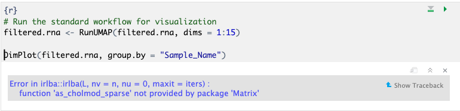

Solution: Downgrading `Matrix`

If Mac is updated to Sonoma 14.x.x, you may see errors related to gfortran, like:

ld: warning: search path ‘/opt/R/arm64/gfortran/lib/gcc/aarch64-apple-darwin20.2.0/11.0.0’ not found  
ld: warning: search path ‘/opt/R/arm64/gfortran/lib’ not found  
ld: library ‘gfortran’ not found

If that’s the case, please download and install gfortran-12.2-universal.pkg https://cran.r-project.org/bin/macosx/tools/ before proceed.

```r
install.packages("remotes")
remotes::install_version("Matrix", version = "1.6-1")
packageVersion("Matrix")
```

Source: https://cran.r-project.org/bin/macosx/tools/

2. When you run `getBM`…

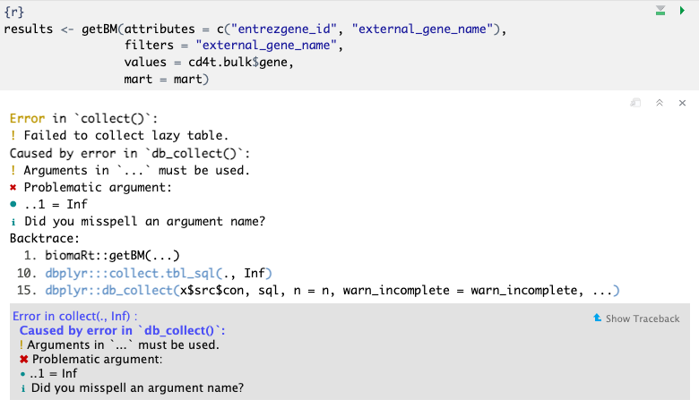

Solution: Downgrading `dbplyr`

```r
devtools::install_version("dbplyr", version = "2.3.4")
```

Source: https://stackoverflow.com/questions/77370659/error-failed-to-collect-lazy-table-caused-by-error-in-db-collect-using

3. When you run `useMart`…

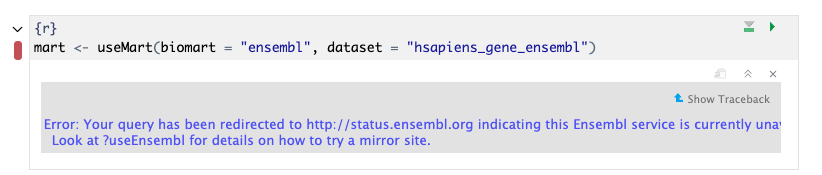

Solution: Go to http://status.ensembl.org to check the status of Ensembl. If it says service is down, wait a few hours and try again.